# EDA: Project Red Wine

# Bivariate Analysis

### Talk about some of the relationships you observed in this part of the investigation. How did the feature(s) of interest vary with other features in the dataset?

Alcohol is definitely one of the major factor in influencing wine quality. The highest mean in Alcohol Volume was found in the highest quality grade (Grade 8) at 12.09%.

### Did you observe any interesting relationships between the other features (not the main feature(s) of interest)?

Even though alcohol is the major factor, it is interesting to note its correlation with Quality was actually decreased in the Zero Citric Acid dataset. However, Citric Acid and Alcohol do not have a strong relation. So perhaps some other factors were influencing this result.

### What was the strongest relationship you found?

The strongest relationship is between Acid and pH with the correlation score of 0.68.

# Multivariate Plots Section

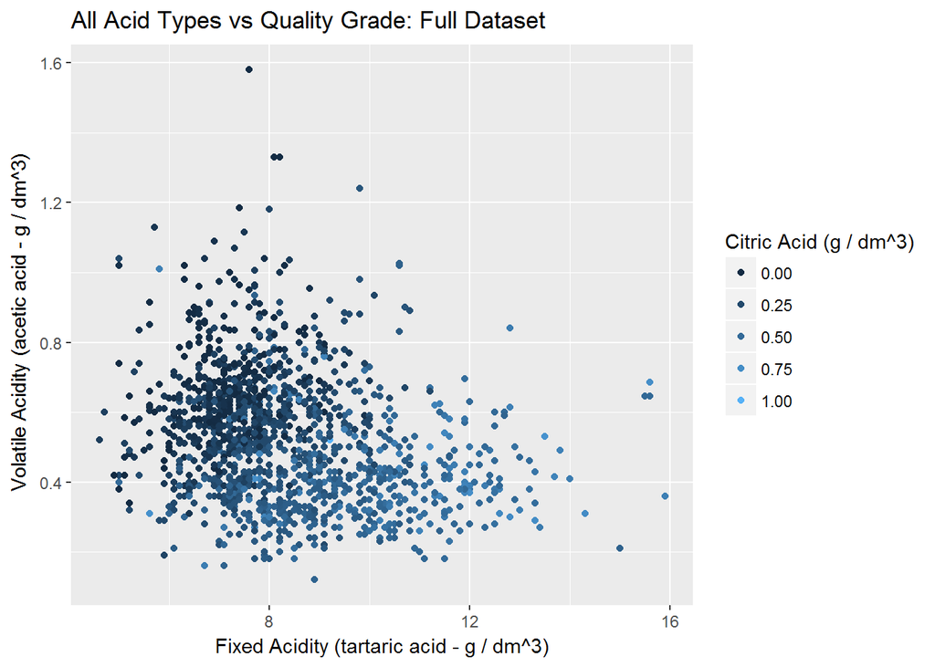

A high number of low citric acid is situated when fixed.acidity is less than 10(g/dm^3). The higher the value for fixed.acidity, the higher the value for citric acid.

We will then map these two type of acids against Quality where the citric acid do not exist.

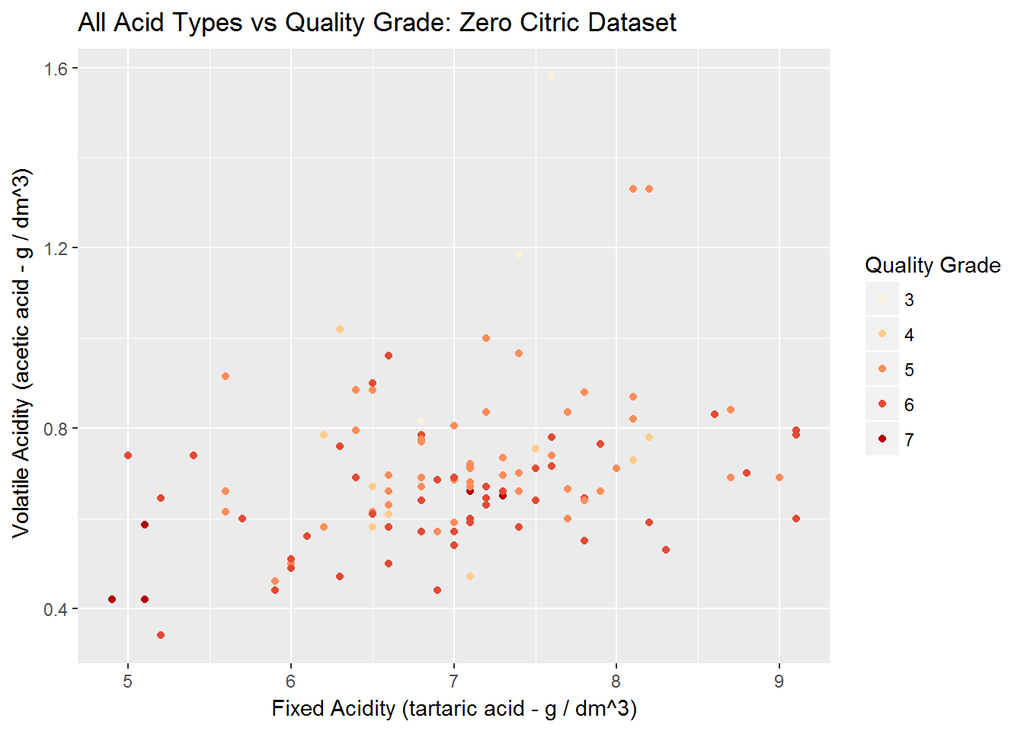

No surprising result there since we have shown previously that this dataset did not contain any wine under Grade 8, hence, the Quality Grade value only ends at 7.

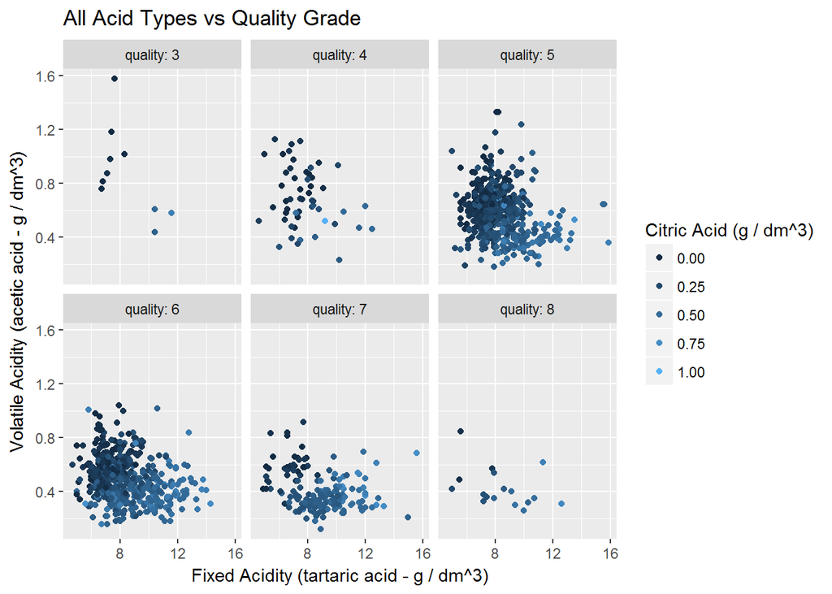

Most of the points were concentrated around Grade 5 and Grade 6, which is consistent with the Quality Histogram from the Univariates Section. All of them have similar fixed acid content. However, we can see some pretty high existence of the citric acid and the low value of volatile acid in Grade 8 compares to other Grades.

# Multivariate Analysis

### Talk about some of the relationships you observed in this part of the investigation. Were there features that strengthened each other in terms of looking at your feature(s) of interest?

Once you arrange the acid variables into your wine quality layout, you can see more clearly how some of the variables influenced the quality.

### Were there any interesting or surprising interactions between features?

Grade 8 Quality panel was missing from zero.citric dataset, and this is not surprising because all the data inside Grade 8 contains some amount of citric acid.

# Final Plots and Summary

### Plot One

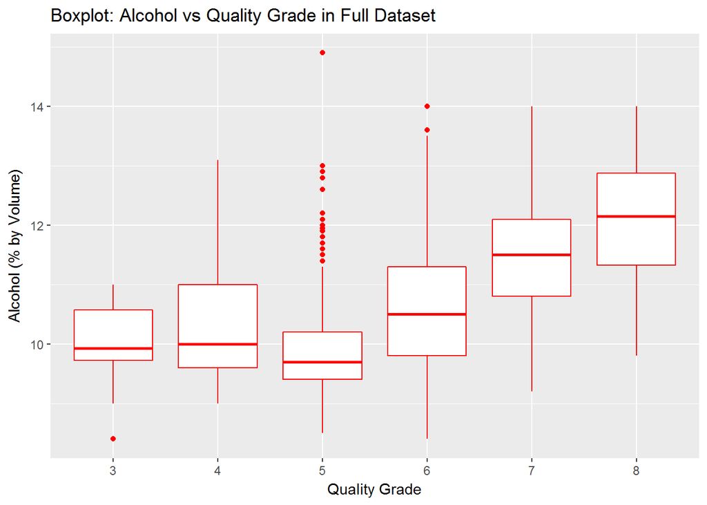

### Plot Two

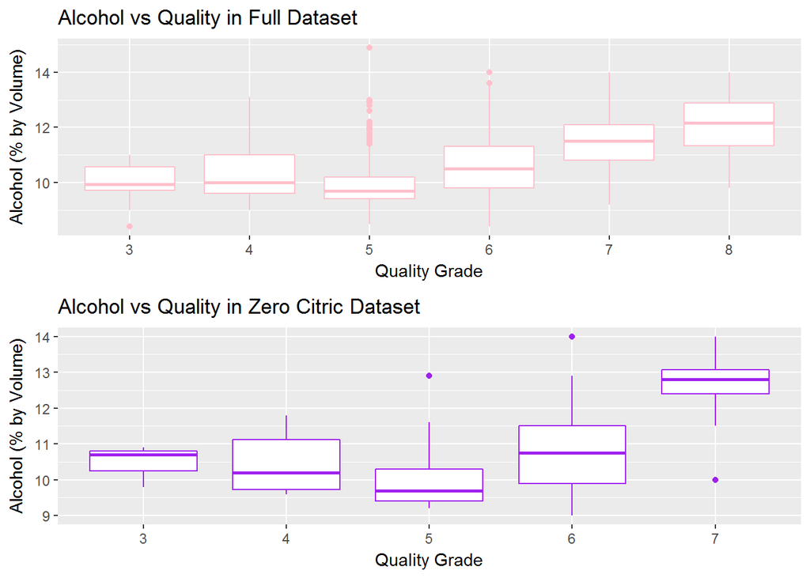

### Description Two

This is an interesting comparison between the Full Dataset and Zero Citric Dataset. It comes out when I found the correlation score between Alcohol and Quality was actually lower in Zero Citric Dataset compared to the Full Dataset (0.6 vs 0.4). I suspect the lower correlation might be due to the missing data from Grade 8 Quality, since Zero Citric Dataset does not contain any data from Grade 8.

### Plot Three

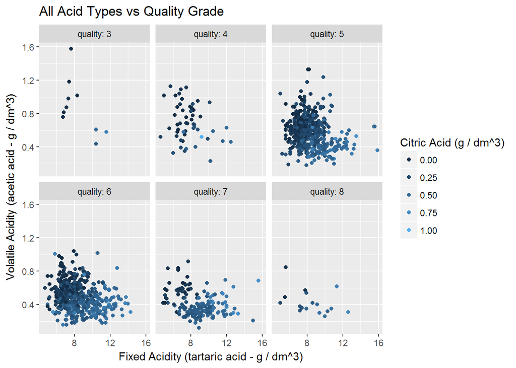

# Reflection

### Difficulties:

As a non-wine drinker, this project may not look that interesting in the first glance. There’s a lot of information I’m not familiar with, and I did struggle with my decision on whether to keep, or remove some of the outliers found in this dataset. At the end of the day, I decided to keep it since it gives me a better understanding on the overall picture. In future analysis, I may remove some of the outliers once I got a better understanding on the factors that influence wine quality.

### Success:

Although Citric Acid did not strongly influence wine quality, it’s still one of the item where it’s ‘good to have’. You can still have low quality wine even when you have Citric Acid, however, if have all the complete ingredients, the appearance of Citric Acid may push your wine quality to a grade higher. I’m glad that I went to look at the Zero Citric dataset in more details, rather than discard them as an outlier to be ignored in the analysis.

Also, from my research on EU regulation, I found that we have three datapoints that exceeded the EU’s permitted level of Sulfur Dioxide (SO2). We do not know if this is simply an error, or if the wine samples came directly from the manufacturer rather than the shelf.

### Future works:

This dataset only contains the chemical structure of red wine vs the output variable that was graded by wine experts. However, when you see any wine advertisements, they appealed to their customers with photos of their vineyard and grapes, we rarely see they advertised it with Alcohol volume for eg, (or if they do, it’s part of the Government Regulation to publish the alcohol level).

So, are they some other factors that we might miss? Does your vineyard location or your species of grapes, influence your wine quality? We might do further analysis to confirm if this is the correct hypothesis.